# Final

2022-03-10

# 1 Instructions

- **Complete the problem sets below.**
- **Write all of your code in the `.Rmd` file that you will turn in with the knitted `html` file, with zero dependencies on external files other than the `final_data` object that I created, and that you will load in from a GitHub URL.**
- **Use your best judgment on the number of significant figures to include in your reported results. Don’t just report the default. Think about the context and any comparisons you are making, as well as the scale of the measurements, and then choose an appropriate display precision and unit of measurement.**
- **Write your code, display your results, and interpret results in the areas indicated in the instructions of each problem.**
- **Do not just print out the `data.frame` of results. Put your results into a formatted table using `kable` or a similar package.**
- **Read about the data before starting the problems to understand what data is available to you.**
- **Save yourself some extra work by reusing previous results where applicable**
- **Write your code as cleanly as possible, with comments about the steps you are taking along the way. The cleaner and better-explained your code, the easier it is for me to see whether you got most of the steps right, and the more likely I will be able to give you partial credit for getting the code mostly right even if your numerical results are wrong.**
- **Keep your written answers concise, but also specific to the question at hand.**
- **For some questions, I ask you to do more computations than I ask you to report on. Still do the computations I ask you to do, because you will likely use some of them on future questions.**

**Not following these instructions may result in:**

- **Doing more work than necessary**
- **Partial loss of credit on particular responses**
- **Having to amend your final and turn it in again for a loss of a half a point (e.g. if your `.Rmd` file is not self-contained or your reported tables are not formatted)**

# 2 Grading

- **Every single task where I ask you to report or interpret the results is worth the same amount of points out of the total 23 points that is distributed across questions.**
- **I will give half credit on reported results and three-quarters credit on interpreted results that are incorrect, but where you did the computation step mostly right (i.e. minor syntactical or logical error as opposed to serious conceptual error).**
- **Again, for some questions, I ask you to do more computations than I ask you to report on. Still do the computations I ask you to do, because I’ll also only give you half credit on results reported from incomplete computations.**
- **I will give 10% credit to vaguely-worded written answers where it is hard to understand what you are saying at all.**
- **I will forgive minor rounding errors, etc., entirely.**
- **Two freebie points for good-faith effort at completing the entire final.**
- **There are opportunities for extra credit (and fun extra analysis) if you so desire.**

# 3 Spoiler alert

**You will not construct any (parent single decrement) life tables for this final.**

# 4 Setup

```r
# Install pacman
if (!require("pacman")) install.packages("pacman")
```

```r
# p_load function loads packages if installed, or install then loads otherwise
pacman::p_load(dplyr, ggplot2, knitr, kableExtra, readr, stringr)
```

# 5 Data collection

```r
final_data <- readRDS(url("https://github.com/hanowell/uwsoc533a-final/blob/main/data/final_data.rds?raw=true"))
```

# 6 About the data

## 6.1 Context

**All of the data used for the final applies to periods or cohorts in the U.S.**

## 6.2 Data sources

**Data sets providing exposures, population counts, and mortality statistics come from the Human Mortality Database (HMD). Data sets providing fertility statistics come from the Human Fertility Database (HFD).**

## 6.3 Top-level data structure

**You’ve just loaded a `list` of all the `data.frame`s you need to complete this final. To access a given `data.frame` in the `list`, write code like this:**

```r
final_data[["[name of data.frame]"]]
```

**For example, the code below returns the head of the `us_asmr` data:**

```r
head(final_data[["us_asmr"]])
```

```
##   Year Age   Female     Male    Total OpenInterval
## 1 1933   0 0.054177 0.068175 0.061292        FALSE
## 2 1933   1 0.004394 0.005021 0.004712        FALSE
## 3 1933   5 0.001492 0.001769 0.001633        FALSE
## 4 1933  10 0.001169 0.001529 0.001350        FALSE
## 5 1933  15 0.002094 0.002474 0.002284        FALSE
## 6 1933  20 0.003124 0.003458 0.003289        FALSE
```

## 6.4 Data dictionaries

### 6.4.1 `us_asfr`

- **`Year`: The one-year period during which ASFR was measured**
- **`Age`: Starting age of one-year age group applicable to `ASFR` in `Year`**
- **`ASFR`: ASFR for the `Age` group in `Year`**
- **`OpenInterval`: Boolean indicator for whether or not the age interval is open to the left or right**

### 6.4.2 `us_asmr`

**Annual period age-specific mortality rates (ASMRs) for five-year age groups by sex for the U.S. from 1933 through 2016.**

- **`Year`: The one-year period during which ASMR was measured**
- **`Age`: Starting age of one-year age group applicable to ASMR in `Year`**
- **`Female`: Female ASMR for the `Age` group in `Year`**
- **`Male`: Male ASMR for the `Age` group in `Year`**
- **`Total`: ASMR for the `Age` group in `Year`**
- **`OpenInterval`: Boolean indicator for whether or not the age interval is open to the right**

### 6.4.3 `us_births`

**Annual period age-specific birth counts for one-year age groups of mothers for the U.S. from 1933 through 2016.**

- **`Year`: The one-year period during which births were counted on 1 January**
- **`Age`: Starting age of one-year age group of the mother**
- **`Total`: January 1st birth count for the `Age` group in `Year`**
- **`OpenInterval`: Boolean indicator for whether or not the age interval is open to the left or right**

### 6.4.4 `us_totbirths`

**Annual period total birth counts for one-year age groups of mothers for the U.S. from 1933 through 2016.**

- **`Year`: The one-year period during which births were counted on 1 January**
- **`Total`: January 1st birth count in `Year`**

### 6.4.5 `us_deaths`

**Annual period age-specific death counts for five-year age groups for the U.S. from 1933 through 2016.**

- **`Year`: The one-year period during which death count was measured**
- **`Age`: Starting age of one-year age group applicable to death count in `Year`**
- **`Female`: Female death count for the `Age` group in `Year`**
- **`Male`: Male death count for the `Age` group in `Year`**
- **`Total`: Total death count for the `Age` group in `Year`**
- **`OpenInterval`: Boolean indicator for whether or not the age interval is open to the right**

### 6.4.6 `us_deaths_despair`

**Annual period age-specific death counts due to “despair” (alcoholic liver disease, alcohol abuse, drug abuse, and suicide or self-inflicted injury) for five-year age groups for the U.S. in 2015.**

- **`Age`: Starting age for the age group**
- **`D_despair`: Number of deaths in `Age` group due to despair**

### 6.4.7 `us_exposures`

**Annual period age-specific person-year (ASPY) approximations by sex for five-year age groups for the U.S. from 1933 through 2016.**

- **`Year`: The one-year period during which ASPY was measured**
- **`Age`: Starting age of one-year age group applicable to ASPY in `Year`**
- **`Female`: Female ASPY for the `Age` group in `Year`**
- **`Male`: Male ASPY for the `Age` group in `Year`**
- **`Total`: Total ASPY for the `Age` group in `Year`**
- **`OpenInterval`: Boolean indicator for whether or not the age interval is open to the right**

### 6.4.8 `us_population`

**Age-specific population counts by sex and day of year (January 1st vs. December 31st) for five-year age groups for the U.S. from 1933 through 2016.**

- **`Year`: The one-year period during which population counts were measured**
- **`Age`: Starting age of one-year age group applicable to ASPY in `Year`**
- **`Female1`: Female population count for the `Age` group on January 1st of `Year`**
- **`Male1`: Male population count for the `Age` group on January 1st of `Year`**
- **`Total1`: Total population count for the `Age` group on January 1st of `Year`**
- **`Female2`: Female population count for the `Age` group on December 31st of `Year`**
- **`Male2`: Male population count for the `Age` group on December 31st of `Year`**
- **`Total2`: Total population count for the `Age` group on December 31st of `Year`**
- **`OpenInterval`: Boolean indicator for whether or not the age interval is open to the right**

### 6.4.9 `us_ppr`

**Parity progression ratios (PPRs) for baseline parity 0 through 3 for the U.S. 1918, 1943, and 1968 birth cohorts, respectively.**

- **`Cohort`: Calendar year of birth cohort**
- **`PPR[A]_[B]`: Parity progression ratio for moving from parity `A` to parity `B`**
- **`OpenInterval`: I’m guessing this is an indicator for whether or not the birth `Cohort` is still open; just assume that all of these cohorts have completed their reproductive lifespan**

### 6.4.10 `us_fltper`, `us_mltper`, and `us_bltper`

**These are the annual female, male, and total population life table for five-year age groups for the U.S. from 1933 through 2016. They have all of the columns you expect from a life table, with `Age` being the starting age of each age group, and `Year` referring to your annual period from which the life table calculated.**

### 6.4.11 `us_fltper_2009`

**Annual female life table for one-year age groups for the U.S. in 2009.**

# 7 Annual age-specific person-year (ASPY) approximations

## 7.1 Computation

**Use the population counts provided to approximate for each sex (and for both sexes combined) the age-specific person-years (ASPY) lived during each individual calendar year period between 1 January 2005 and 1 January 2016 (i.e. for 2005 through 2015), respectively, under the following assumptions:**

- **Linear (and constant) growth in person-years during the period**
- **Constant (but not necessarily linear) growth in person-years during the period**

## 7.2 Report results

**Report total (both sexes combined) age-specific person-years lived in the 2015 calendar-year period below in a table with the following structure:**

- **`Age` as defined in the original data set**
- **`py_linear`: The linear growth approximation of ASPY**
- **`py_constant`: The constant growth approximation of ASPY**
- **`py_hmd`: The ASPY approximation for the same population and period from the original HMD data source (i.e. `us_exposures`)**

## 7.3 Interpret results

**For the 2015 total population, compare these three ASPY approximations to one another. Then discuss the implications of these results for the linear and constant growth assumptions, including any variation by age group if applicable.**

**Answer below:**

# 8 Annual crude growth rate (CGR) approximations by age and for the total population

## 8.1 Computation

**Using the person-year approximations you made in the previous problem, estimate the annual CGR for each age and sex as well as for the total population for each calendar year period from 2005 through 2015 using all three person-year approximations, respectively:**

- **Linear (and constant) growth in person-years during the period**
- **Constant (but not necessarily linear) growth in person-years during the period**
- **Person-years as approximated by the HMD**

## 8.2 Report results

### 8.2.1 Age-specific CGR

**Report the age-specific CGR results for both sexes combined for 2015 in a table below with the following structure:**

- **`Age` as defined in the original data set**
- **`cgr_linear`: age-specific CGR under the linear growth approximation of ASPY**
- **`cgr_constant`: age-specific CGR under the constant growth approximation of ASPY**
- **`cgr_hmd`: age-specific CGR using ASPY from the original HMD data source**

### 8.2.2 Population CGR

**Report the CGR results for 2005 through 2015 for the total population (both sexes combined, not age-specific) in a table below with the following structure:**

- **`Year`: The calendar-year period to which the CGR estimates apply**
- **`cgr_linear`: CGR under the linear growth approximation of ASPY**
- **`cgr_constant`: CGR under the constant growth approximation of ASPY**
- **`cgr_hmd`: CGR using ASPY from the original HMD data source**

## 8.3 Interpret results

**Describe the temporal pattern in CGR (as calculated from the HMD person-years approximations) from 2005 through 2015. Describe at least two alternative hypotheses for the pattern you see. You may refer only to the total population CGR trend, but I will give an extra point for correct reference and demonstration of any age-specific pattern in CGR.**

**Answer below:**

# 9 Principal period rates in 2015

## 9.1 Computation

**For both sexes combined, compute the principal period rates that contributed to the CGR (both sexes combined, not age-specific) for each calendar-year period from 2005 through 2015. Hint: For each year, you will have to infer the crude rate of net migration (CRNM) because you can’t calculate it directly.**

## 9.2 Report results

**Report your results for both sexes combined in a table below with the following structure:**

- **`Year`: The year to which the principal period rates apply**
- **`cbr/cdr/cnmr`: Separate columns for each of the principal period rates of interest**

## 9.3 Interpret results

**Expand on your interpretation of the CGR results from the previous problem in light of the patterns you see in the principal period rates.**

**Answer below:**

# 10 Age-standardized crude death rate (CDR) before, during, and recovering from the Great Recession

## 10.1 Computation

**Using 2005 as a baseline standard, compute the age-standardized CDRs by sex (including both combined) for each of the calendar years from 2005 through 2015.**

## 10.2 Report results

**Report your results in three tables below (one for males, one for females, one for both sexes), each with the following structure:**

- **`Year`: The year of the CDR estimate**
- **`cdr`: The un-standardized CDR**
- **`ascdr`: The standardized CDR**

## 10.3 Interpret results

**Within the context of the Great Recession, construct at least one hypothesis to explain the comparison between the temporal patterns in standardized vs. un-standardized CDRs from 2005 through 2015.**

**Answer below:**

# 11 CDR difference decomposition, 2015 vs. 2005

## 11.1 Computation

**Decompose the difference in the un-standardized CDR between 2015 and 2005 (i.e. CDR(2015) - CDR(2005)) into its age-specific mortality schedule and age structure effects for each sex, respectively, including both sexes combined. Also compute the total mortality schedule and age structure effects for all ages combined (respectively for each sex, including both sexes combined).**

## 11.2 Report results

### 11.2.1 Age-specific effects

**Report the age-specific decomposition results in three tables below (one for males, one for females, one for both sexes combined), each with the following structure:**

- **`Age`: The start year of the age group**
- **`m_effect`: The age-specific mortality schedule effect**
- **`c_effect`: The age-specific age structure effect**
- **`total_effect`: The total age-specific effect**

### 11.2.2 Total effects

**Report the decomposition results for all ages combined in a table below with the following structure:**

- **`sex`: One row for Male, Female, and Total, respectively, where “Total” means both sexes combined**
- **`m_effect`: The age-specific mortality schedule effect**
- **`c_effect`: The age-specific age structure effect**
- **`total_effect`: The total age-specific effect**

## 11.3 Interpret results

**Within the context of the intervening Great Recession and its aftermath, interpret the age-specific and total decomposition of the change in CDR from 2005 to 2015. Make explicit reference to the interpretation of the signs and magnitudes of the effects themselves. Highlight any differences in the effects by sex that stand out to you, being specific about what the sex differences in the effects mean.**

**Answer below:**

# 12 Cohort total Fertility Rate (TFR) from parity progression ratios (PPR)

## 12.1 Computation

**Assuming (contrary to fact) that the maximum parity is 4, compute the cohort TFR from the PPRs in the U.S. in 1918, 1943, and 1968, respectively.**

## 12.2 Report results

**Report the results in a table below with the following structure:**

- **`Cohort`: The birth cohort to which the cohort TFR estimate applies**
- **`TFRc`: The estimated cohort TFR**

## 12.3 What extra data do we need beyond what is available to calculate the cohort TFR correctly from PPRs?

**Answer below:**

## 12.4 What would have to be true about PPRs above parity 4 for the cohort TFRs you calculated to be correct?

**Answer below:**

# 13 PPR trend

**Below is a plot of the PPRs for parity 0 through 3 comparing 1918, 1943, and 1968.**

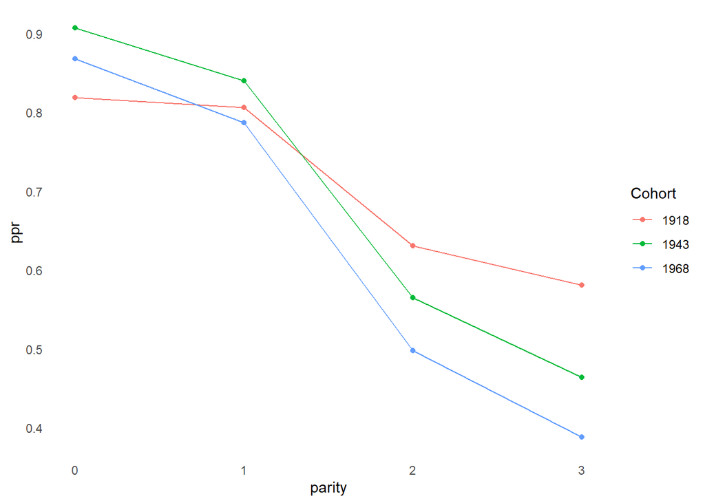

## 13.1 PPRs for 1918 vs. both later birth cohorts

**With reference to definition of a PPR and the proximate determinants of fertility, provide at least one potential explanation for the differences between the PPR curve of 1918 vs. both of the later cohorts.**

**Answer below:**

## 13.2 PPRs for 1943 vs. 1968

**With reference to definition of a PPR and the proximate determinants of fertility, provide at least one potential explanation for the differences between the PPR curves of 1943 and 1968.**

**Answer below:**

# 14 TFR, gross reproduction rate (GRR), net reproduction rate (NRR), generality fertility rate (GFR), and crude birth rate (CBR)

## 14.1 Computation

**Calculate the TFR, GRR, NRR, GFR, and GFRc (GFR estimated from CBR assuming ${}_{\beta - n}C_\alpha = 0.25 = C$) for each of the years from 2005 through 2015. Yes, you can estimate each of these using the data provided, even if you have to do some of the estimation indirectly. Feel free to assume the sex ratio at birth (SRB) is a constant 1.05 males per female.**

**Hints:**

- **Remember that some of these period rates are functions of each other**
- **It will be easier to get to GRR by applying SRB to fertility rates rather than trying to calculate it from TFR, SRB, and $p(A_m)$**

## 14.2 Report results

**Report the results below in a table with the following structure:**

- **`Year`: The period for which the rate applies**
- **`[tfr/grr/nrr/gfr/cbr/gfr_c]`: Six separate columns for each of the period rates requested**

## 14.3 How well does the rule of thumb GFR = CBR/0.25 predict actual GFR?

**Answer below (you can compare the two simply by summarizing the central tendency and dispersion of their differences, if you like, but feel free to get creative):**

# 15 Multiple decrement table for U.S. 2015: Deaths by despair vs. all other causes

## 15.1 Computation

**Construct a period multiple decrement table for deaths by despair vs. all other causes for both sexes combined in the U.S. in 2015.**

**Hints:**

- **You will need to recover the despair mortality rate and the mortality rate due to all other causes from the despair death counts, total death counts, and all-cause mortality rates.***
- **The despair death count’s open-ended age interval is younger than the open-ended interval for the all-cause mortality data. Just make a simple assumption to impute the despair mortality for the open-ended interval in the life table (e.g. assume that the hazard ratios for the extra age intervals in the life table are the same as it is for open-ended interval in the cause-specific death count data).**

## 15.2 Report results

**Report the multiple decrement table with column `Age`, as well as columns `mx_[d/o]`, `dx_[d/o]`, and `lx_[d/o]`, where `d` is for “despair” and `o` is for “other” causes of death, respectively. These column naming conventions should be familiar to you by now.**

## 15.3 Interpret results

**Describe the age pattern of age-specific mortality of probability of death due to despair compared to deaths due to all other causes.**

**Answer below:**

# 16 Cause-deleted life table for U.S. 2015 without deaths by despair

## 16.1 Compute

**Employing the proportional hazards assumption and accompanying procedure that we learned in class, construct a cause-deleted life table for both sexes combined in the U.S. in 2015 that excludes mortality due to despair.**

## 16.2 Report results

**Report the cause-deleted life table below with the typical life table columns that we’ve reported so many times in previous assignments (only they should be calculated for the cause-deleted case, of course).**

## 16.3 Interpret results

**With reference to the appropriate parent life table, compare the mortality experience with vs. without deaths due to despair in terms of: (1) differences in life expectancy at birth, age 20, and age 40; (2) differences in the probability of surviving from birth to age 30; and (3) differences in the probability of surviving from age 40 to age 60. Hint: Relative differences or ratios may in some ways be more informative than differences, and vice versa.**

**Answer below**

# 17 Population projection from 2005 to 2015

## 17.1 Computation

**Assuming a closed population, project the female population of the U.S. by age from 2005 to 2015 assuming 2005 age- and sex-specific vital rates remain constant over the projection period. Assume the sex ratio at birth is 1.05 males per female.**

**Hints:**

```r
# Five-year birth counts, female exposures, and ASFR in 2005
five_year_asmr_2005 <- final_data[["us_births"]] %>%
  dplyr::filter(Year == 2005, Age %>% dplyr::between(15, 49)) %>%
  dplyr::select(Age, Total) %>%
  dplyr::mutate(
    Age = Age %>%
      cut(breaks = seq(15, 50, 5), right = FALSE, labels = seq(15, 45, 5)) %>%
      as.character() %>%
      as.integer()
  ) %>%
  dplyr::with_groups(Age, summarize, births = sum(Total)) %>%
  dplyr::left_join(
    final_data[["us_exposures"]] %>%
      dplyr::filter(Year == 2005) %>%
      dplyr::select(Age, Female)
  ) %>%
  dplyr::mutate(ASFR = births/Female)
# Population counts by uniform five-year age intervals
pop_counts_actual_2015 <- final_data[["us_population"]] %>%
  dplyr::filter(Year == 2015) %>%
  dplyr::select(Age, Female1) %>%
  dplyr::mutate(Age = if_else(Age < 5, 0L, Age)) %>%
  dplyr::with_groups(Age, summarize, actual_size = sum(Female1))
# Proceed with your projection code below:
# ...
```

## 17.2 Report results

**Report the results below in two tables with the following structure.**

- **`Age`: Starting age of the age interval**
- **`N_2005`: Age-specific starting population count on 1 Jan 2005**
- **`N_2015_proj`: Projected age-specific population count on 1 Jan 2015**
- **`N_2015_actual`: Actual age-specific population count on 1 Jan 2015**

## 17.3 Interpret results

**Compare the projected to the actual population in 2015. What could our projection model be missing that could explain any differences you see?**

**Answer below:**

# 18 Stable equivalent population predictions

**Below, I construct a `data.frame` of ratios between 2007 vs. 2005 age-specific fertility rates, as well as the same ratios comparing 2009 vs. 2007.**

```r
asfr_ratios <- final_data[["us_asfr"]] %>%
  dplyr::filter(Year %in% c(2005, 2007, 2009)) %>%
  dplyr::arrange(Age, Year) %>%
  dplyr::group_by(Age) %>%
  dplyr::mutate(ratio = ASFR / dplyr::lag(ASFR)) %>%
  dplyr::filter(!is.na(ratio)) %>%
  dplyr::mutate(comparison = dplyr::case_when(
    Year == 2007 ~ "2007 vs. 2005",
    Year == 2009 ~ "2009 vs. 2007"
  )) %>%
  dplyr::select(Age, comparison, ratio)
```

**Below is a plot of ratios between the 2007 vs. 2005 age-specific fertility rates and the 2009 vs. 2007 age-specific fertility rates, respectively. Notice how the age-specific fertility rates increased from 2005 to 2007 for most high-fertility age groups (and increased especially at older ages). By comparison, fertility below age 40 decreased from 2007 to 2009 (two years into the Great Recession).**

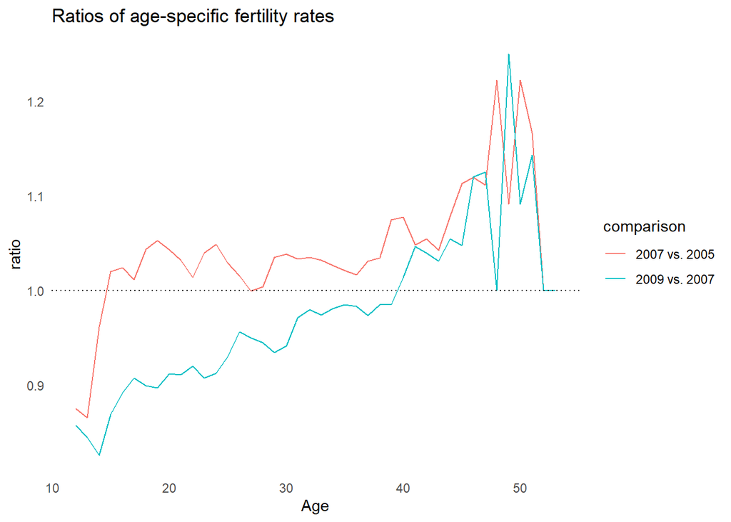

**We will compute female stable equivalent populations in 2009 under two scenarios:**

- **The prevailing age-specific vital rates in 2009**
- **The age-specific vital rates in 2009 had ASFR ratios comparing 2009 to 2007 been the same as they had been comparing 2007 to 2005**

**Below, I construct the age-specific fertility and mortality data you will use to complete this task. Read the code and the comments to see what I’m doing.**

```r
# Construct the ASFR data
us_asfr_2009 <- final_data[["us_asfr"]] %>%
  # Pull the actual 2007 ASFRs
  dplyr::filter(Year == 2009) %>%
  # Join to the appropriate ASFR ratios
  dplyr::left_join(
    asfr_ratios %>% dplyr::filter(comparison == "2007 vs. 2005")
  ) %>%
  dplyr::mutate(ASFR_alt = ASFR * ratio)
# Construct the ASMR and life table data
us_fltper_2009 <- final_data[["us_fltper"]] %>%
  dplyr::filter(Year == 2009)
```

**Below is a plot of the actual and alternative 2009 ASFRs**

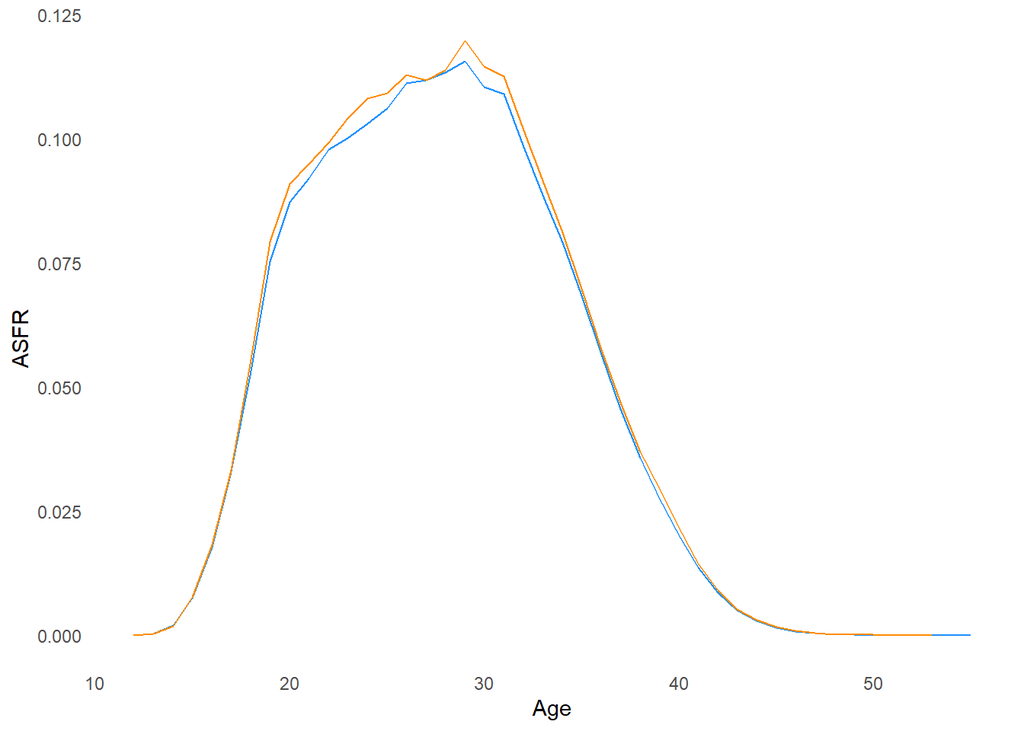

## 18.1 Estimate the stable equivalent populations under the two scenarios

**Estimate the stable equivalent population age structure, birth rate, death rate, and intrinsic growth rate under both scenarios of interest, assuming a closed one-sex (female) population.**

## 18.2 Report results

### 18.2.1 Stable age structures

**Report the stable age structure under both scenarios in a table below with the following structure:**

- **`Age`: Age at the beginning of the age interval**
- **`cx_actual`: The actual female age structure in 2009**
- **`cx_stable_base`: The stable age structure under the 2009 ASFRs**
- **`cx_stable_alt`: The stable age structure under the alternative 2009 ASFRs**

### 18.2.2 Intrinsic rates

**Report the stable equivalent birth, death, and intrinsic growth rates in a table below with the following structure:**

- **`rate_name`: Row for birth, death, and growth**
- **`rate_value`: Value for the stable rate in question**

## 18.3 TFR effect on the intrinsic growth rate in the stable equivalent populations

**Using $\LaTeX$, show the effect of the change in TFR between the alternative and baseline scenarios on the intrinsic growth rate of the stable equivalent population as a function of the generation length $T$, plugging in the actual values of the TFRs and simplifying. Show your work in $\LaTeX$ and in code. You don’t need to estimate $T$.**

**Answer below:**

## 18.4 Interpret results

**Compare the actual, baseline stable equivalent, and alternative stable equivalent population structures and intrinsic rates and explain the differences between them with reference to the underlying rate schedules. I will give you 1 whole bonus point if you correctly employ lessons about the comparative statics of fertility effects on stable age structure, and another whole bonus point if you correctly employ our lessons on fertility effects on the stable death rate.**

**Answer below:**

# 19 Population momentum in 2009

**I wasn’t able to walk you through the way to compute momentum in code, so this question is worth a whole point of extra credit.**

## 19.1 Compute

**Calculate the population momentum factor for U.S. 2009 female population, and using the actual ASFRs.**

## 19.2 Report results

**Report the population momentum factor in a full sentence below.**

**Answer below:**

## 19.3 Interpret results

**Explain what the reported population momentum factor means in a full sentence below.**

**Answer:**